# **Modelos de regresión**

```
there are higher-order terms (interactions) in this model
consider setting type = 'predictor'; see ?vif
```

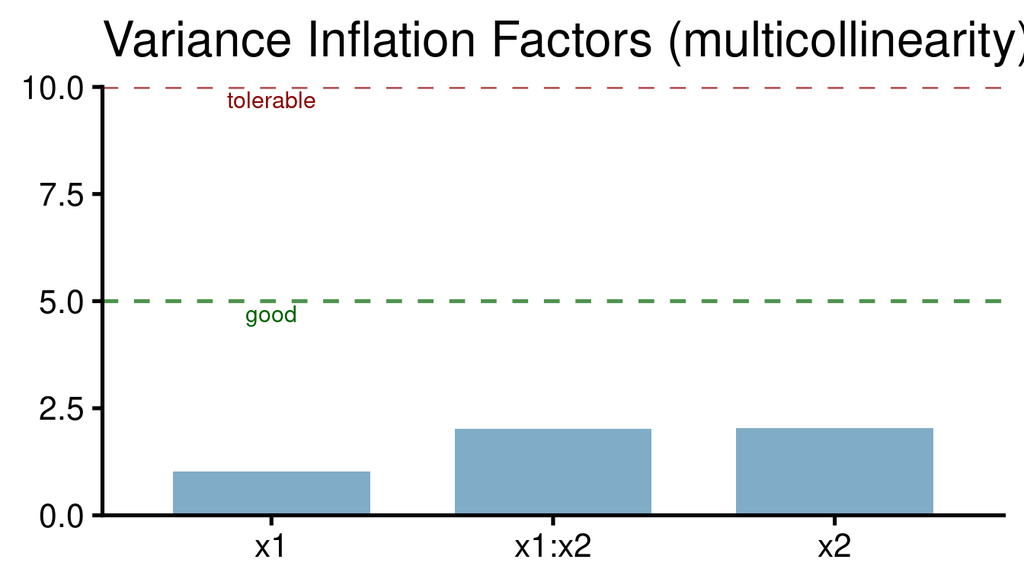

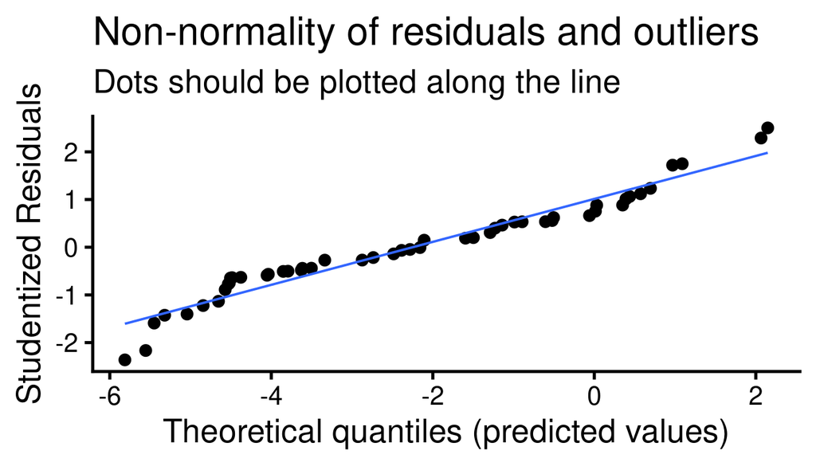

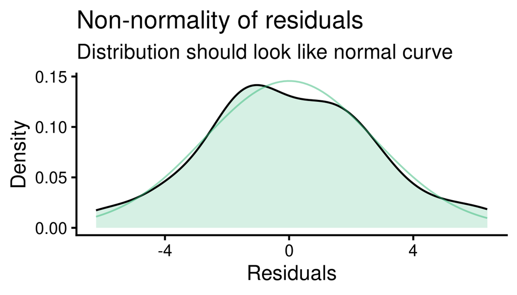

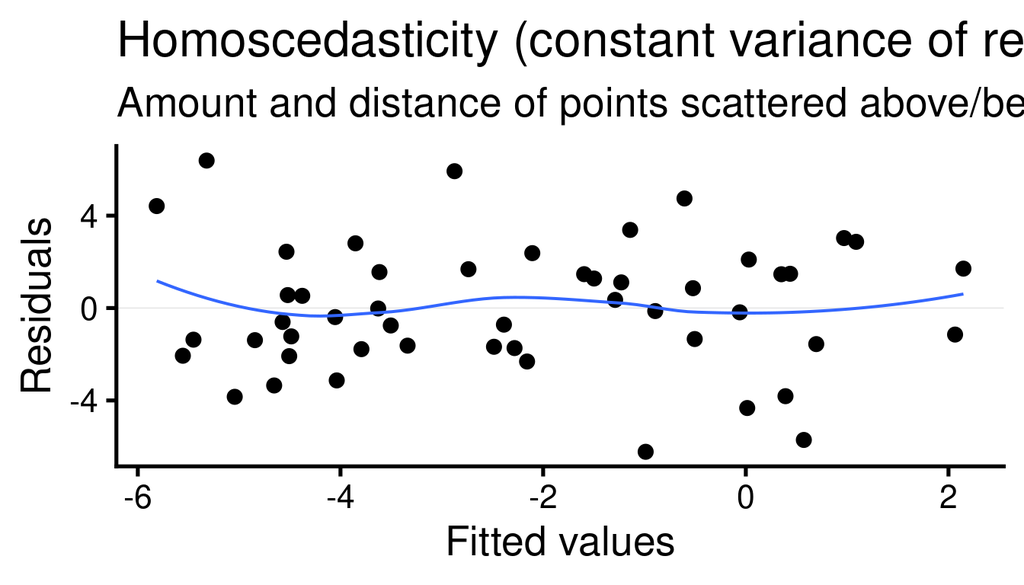

```r
plot_model(xy_mod_intr, type = "diag")
```

**Interpretación del modelo**

Cuadro con los coeficientes:

```
            Estimate Std. Error t value   Pr(>|t|)
(Intercept)  -4.1930    0.57023 -7.3532 2.6978e-09
x1b           3.5974    0.80607  4.4629 5.1950e-05
x2            1.3274    0.68161  1.9474 5.7610e-02
x1b:x2       -2.9720    0.96227 -3.0885 3.4061e-03
```

**Caso de estudio**

- Chirino F, B Wilink, Araya-Salas M. In prep. **Climatic factors affecting vocal activity in lemur leaf frogs**.

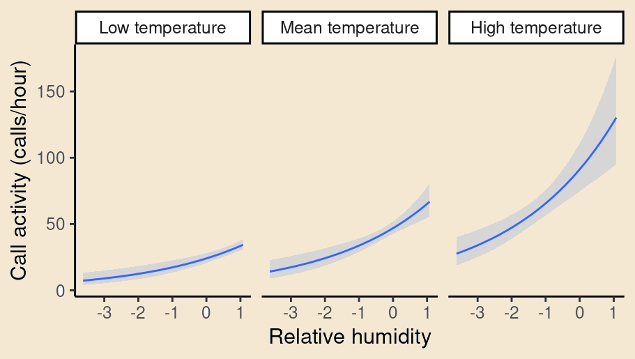

## Lectura: *Understanding ‘it depends’ in ecology: a guide to hypothesising, visualising and interpreting statistical interactions*

Los ecólogos utilizan habitualmente modelos estadísticos para detectar y explicar interacciones entre factores ecológicos, con el objetivo de evaluar si un efecto de interés cambia de signo o magnitud en distintos contextos. El artículo trata de los peligros de interpretan las interacciones estadísticas sin prestar atención a su propiedad fundamental de simetría, o a la escala de medida, ya sea aditiva o multiplicativa. [Acá pueden acceder al artículo](https://onlinelibrary.wiley.com/doi/full/10.1111/brv.12939).

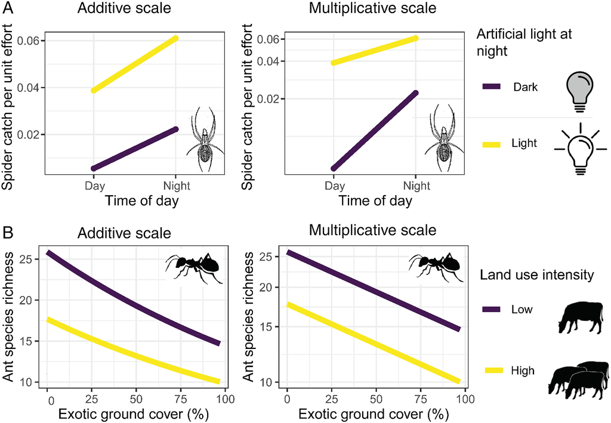

Ejercicio 7

- Modifique el código usado para simular un único predictor asociado aumentando gradualmente el error. Esto se hace aumentando el argumento ‘sd’ en `error <- rnorm(n = n, sd = 2)`.
- Mire cómo los errores más grandes afectan la inferencia (debe volver a correr los modelos)
- Ahora reemplace el término de error con `error <- rexp(n = n, rate = 0.2)`. Esto crea un error con una distribución exponencial (por lo tanto no normal). Se supone que esto es problemático para el poder inferencial de estos modelos. Compare las estimaciones que obtuvo con los valores de la simulación (‘b0’ y ‘b1’). Explore la distribución de los residuos (`plot(nombre_del_modelo)`) para los modelos de error ‘normal’ y ‘exponencial’.
- Se supone que la colinealidad (la presencia de predictores correlacionados) afecta a la estabilidad de la regresión múltiple. El siguiente código crea dos predictores altamente colineales (‘x1’ y ‘x2’). La última línea de código muestra la correlación entre ellos.

**Código**

```r
# definir semilla
set.seed(123)

# numero de observaciones
n <- 50
b0 <- -4
b1 <- 3
b2 <- -2
error <- rnorm(n = n, mean = 0, sd = 1)

#  variables aleatorias
x1 <-  rnorm(n = n, mean = 0, sd = 1)

# hacer x2 muy parecido a x1
x2 <- x1 + rnorm(n = n, mean = 0, sd = 0.3)

cor(x1, x2)
```

```
[1] 0.94642
```

- Construya un modelo de regresión múltiple para estos datos (y ~ x1 + x2). Puede utilizar el mismo código que en la sección Añadir más de un predictor: regresión múltiple.
- ¿Cómo afecta a la inferencia la presencia de predictores colineales? Realice los gráficos de diagnóstico para este modelo (`plot(nombre_del_modelo)`).
- Simule un juego de datos con tres predictores en los que sólo dos de ellos son altamente colineales. Ajuste un modelo de regresión múltiple (y ~ x1 + x2 + x3) para esos datos y observe cómo la colinealidad afecta a la estimación del predictor no colineal.

# 2 Extender los modelos lineales a estructuras de datos más complejas

## 2.1 Modelos lineales generalizados (GLM)

Los GLM nos permiten modelar la asociación a variables respuesta que no siguen una distribución normal. Además, permiten modelar distribuciones que se asemejan más al proceso que generó los datos. El siguiente código crea un juego de datos con una respuesta que representa cuentas (por lo tanto, no normal):

**Código**

```r
# Simulación de datos
set.seed(123)  # Para reproducibilidad
n <- 100  # Número de observaciones
x1 <- rnorm(n)  # Predictor 1: variable normal
x2 <- rnorm(n)  # Predictor 2: variable normal

# Coeficientes reales para la simulación
b0 <- 0.5  # Intercepto
b1 <- 1.2  # Coeficiente para x1
b2 <- -0.8  # Coeficiente para x2

# Calcular lambda (tasa de eventos) utilizando la combinación lineal de los predictores
# En el modelo de Poisson, la tasa esperada lambda está relacionada exponencialmente con los predictores
log_lambda <- b0 + b1 * x1 + b2 * x2
lambda <- exp(log_lambda)  # Lambda debe ser positiva, por eso usamos exp()

# Generar la variable respuesta (cuentas) a partir de la distribución de Poisson
y <- rpois(n, lambda)

# Crear un data frame
xy_datos_pois <- data.frame(x1 = x1, x2 = x2, y = y)

# Mostrar las primeras filas del data frame
head(xy_datos_pois)
```

| x1 | x2 | y |
| --- | --- | --- |
| -0.56048 | -0.71041 | 5 |
| -0.23018 | 0.25688 | 0 |
| 1.55871 | -0.24669 | 17 |
| 0.07051 | -0.34754 | 2 |
| 0.12929 | -0.95162 | 4 |
| 1.71506 | -0.04503 | 15 |

También grafiquemos ‘x1’ *vs* ‘y’:

**Código**

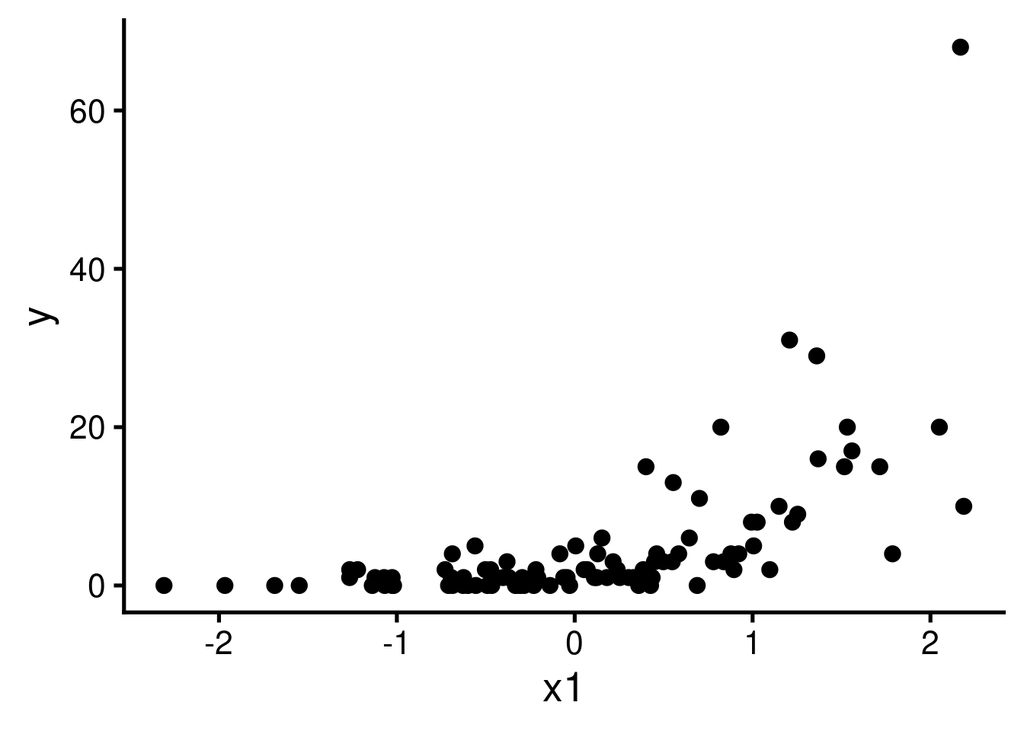

```r
# graficar
ggplot(xy_datos_pois, aes(x = x1, y = y)) +
  geom_point()
```

La relación no parece muy lineal ni la varianza parece ser constante a través de ‘x1’.

Podemos relajar el requisito de la distribución normal con GLMs. `glm()` es una función básica de R que nos ayuda a hacer el truco. Para este ejemplo la distribución más apropiada es *Poisson*. Esto se puede establecer en el argumento `family’ así:

**Código**

```r
glm_pois  <- glm(formula = y ~ x1 + x2, data = xy_datos_pois, family = poisson())
```

Que es equivalente a esto:

$\hat{Y} \sim_{poisson} \beta_{o} + \beta_{1} * x_{1} + \beta_{2} * x_{2}$

Como puede ver el único argumento extra comparado con `lm()` es `family`. El resto es simplemente la “fórmula” y los “datos” con los que ya estamos familiarizados. Así que, de nuevo, podemos aprovechar nuestros conocimientos sobre los modelos lineales para extenderlos a estructuras de datos más complejas.

También necesitamos ejecutar `summary()` para obtener el resultado del modelo:

**Código**

```r
summary(glm_pois)
```

```
Call:
glm(formula = y ~ x1 + x2, family = poisson(), data = xy_datos_pois)

Coefficients:
            Estimate Std. Error z value Pr(>|z|)
(Intercept)   0.4377     0.0867    5.05  4.4e-07 ***
x1            1.2092     0.0565   21.40  < 2e-16 ***
x2           -0.8040     0.0582  -13.80  < 2e-16 ***
---
Signif. codes:  0 '***' 0.001 '**' 0.01 '*' 0.05 '.' 0.1 ' ' 1

(Dispersion parameter for poisson family taken to be 1)

    Null deviance: 920.85  on 99  degrees of freedom
Residual deviance: 110.28  on 97  degrees of freedom
AIC: 347.4

Number of Fisher Scoring iterations: 5
```

**Interpretación del modelo**

Cuadro de los coeficientes (estimados):

```
            Estimate Std. Error  z value    Pr(>|z|)
(Intercept)  0.43769   0.086656   5.0509  4.3971e-07
x1           1.20915   0.056501  21.4007 1.3161e-101
x2          -0.80402   0.058242 -13.8049  2.3824e-43
```

- El modelo nos dice que $\beta_1$ (el tamaño de efecto de ‘x1’) es 1.20915 y que es significativamente diferente de 0 (p = 1.31613^{-101}). Esto se interpreta en realidad como que un aumento de 1 unidad de ‘x1’ resulta en ‘y’ (tasa) en un factor de exp(1.20915) = 3.35064.
- El modelo también nos dice que $\beta_2$ (el tamaño de efecto de ‘x2’) es -0.80402 y que es significativamente diferente de 0 (p = 2.38235^{-43}). Esto significa que un aumento en 1 unidad de ‘x2’ resulta en ‘y’ (tasa) en un factor de exp(-0.80402) = 0.44752.

**Caso de estudio**

- Topp, E. N., Tscharntke, T., & Loos, J. (2022). [**Fire and landscape context shape plant and butterfly diversity in a South African shrubland**](https://onlinelibrary.wiley.com/doi/pdf/10.1111/ddi.13257). *Diversity and Distributions*, 28(3), 357-371.

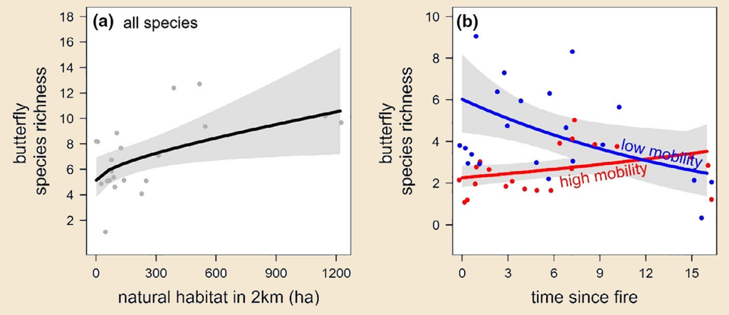

Ejercicio 8

- Intente correr el modelo anterior `lm()` (con una distribución gaussiana), compare los resultados y compruebe los residuos (`plot_model(model_name, type = "diag")`)

Existen muchas otras funciones de distribución y enlace:

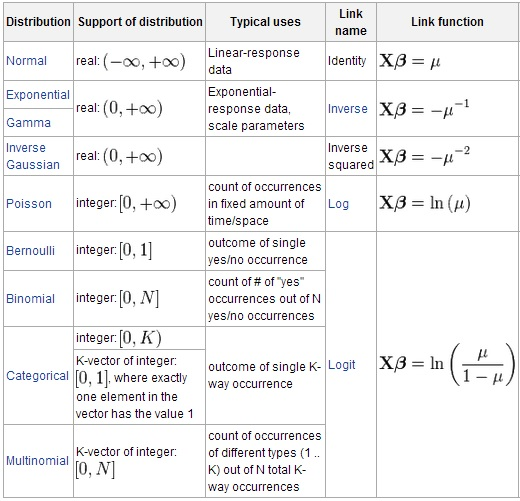

## 2.2 Modelos de efectos variables (modelos mixtos)

A veces nuestros conjuntos de datos incluyen estructuras con varios niveles de organización. Por ejemplo, cuando tomamos muestras de varios individuos de diferentes poblaciones. En esos casos, la variación en el nivel estructural superior (poblaciones) podría impedir la detección de patrones en el nivel inferior (individuos).

**Código**

```r
# x<- 1
# definir semilla
set.seed(28)

# numero de observaciones
n <- 300
b0 <- 1
b1 <- 1.3
poblacion <- sample(0:8, size = n, replace = TRUE)
error <- rnorm(n = n, mean = 0, sd = 2)

#  variables aleatorias
x1 <-  rnorm(n = n, mean = 0, sd = 1)
y <- b0 + poblacion * 2 + b1 * x1 + error

# add letters
poblacion <- letters[poblacion + 1]

# create data set
xy_datos_mixto <- data.frame(x1, y, poblacion)

head(xy_datos_mixto, 10)
```

| x1 | y | poblacion |
| --- | --- | --- |
| 1.54607 | 3.3378 | a |
| 0.56834 | 3.1399 | a |
| -0.63855 | 15.2824 | i |
| 0.98424 | 2.6610 | a |
| 1.05355 | 3.7312 | b |
| -0.82294 | 3.0189 | a |
| -1.32373 | 3.2186 | c |
| 2.17854 | 19.0542 | i |
| 2.26484 | 15.4549 | i |
| -0.77843 | 11.6670 | h |

Podemos explorar la relación entre ‘y’ y ‘x1’ con un gráfico:

**Código**

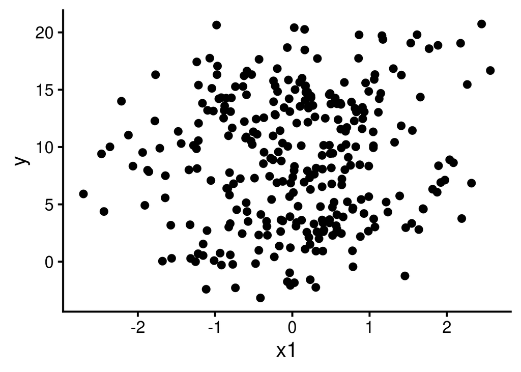

```r
ggplot(data = xy_datos_mixto, aes(x = x1, y = y)) +
  geom_point()
```

¿Puede ver claramente el patrón de asociación entre las dos variables que hemos utilizado para simular los datos? Podemos seguir explorando los datos con un modelo de regresión lineal simple:

**Código**

```r
summary(lm(y ~ x1, data = xy_datos_mixto))
```

```
Call:
lm(formula = y ~ x1, data = xy_datos_mixto)

Residuals:
    Min      1Q  Median      3Q     Max
-11.755  -5.119   0.186   4.602  12.409

Coefficients:
            Estimate Std. Error t value Pr(>|t|)
(Intercept)    8.852      0.325   27.21   <2e-16 ***
x1             0.633      0.329    1.92    0.055 .
---
Signif. codes:  0 '***' 0.001 '**' 0.01 '*' 0.05 '.' 0.1 ' ' 1

Residual standard error: 5.63 on 298 degrees of freedom
Multiple R-squared:  0.0123,    Adjusted R-squared:  0.00895
F-statistic:  3.7 on 1 and 298 DF,  p-value: 0.0554
```

A pesar de haber simulado un $\beta_1$ distinto de cero, no tenemos ninguna asociación significativa según este modelo y la estimación de $\beta_1$ está muy lejos de la simulada. Esta pobre inferencia se debe a que estamos ignorando una característica importante de nuestros datos, la agrupación de las muestras en “poblaciones”.

Los modelos de efectos mixtos (también conocidos como modelos multinivel o modelos de efectos variables) pueden ayudarnos a tener en cuenta estas características adicionales, mejorando significativamente nuestro poder de inferencia. Coloreemos cada una de las poblaciones para ver cómo covarían las variables en cada subgrupo de datos:

**Código**

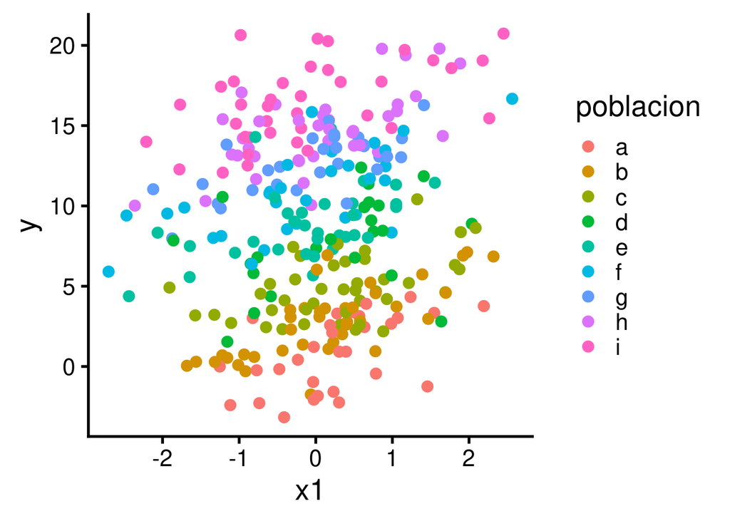

```r
ggplot(data = xy_datos_mixto, aes(x = x1, y = y, color = poblacion)) +
  geom_point()
```

Parece haber un patrón claro de asociación positiva entre x1 e y. El patrón se hace un poco más evidente si mostramos cada población en su propio panel:

**Código**

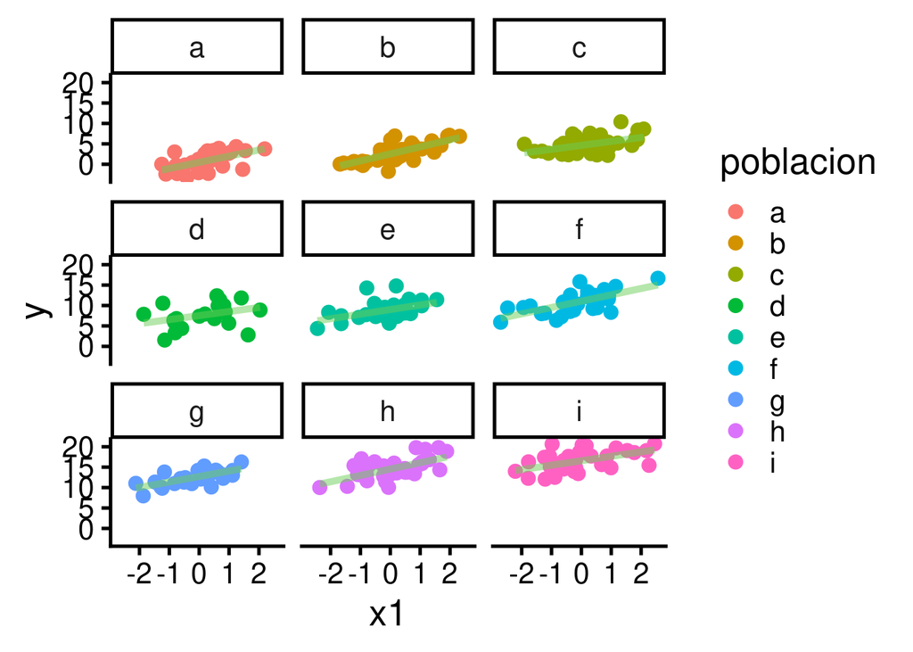

```r
ggplot(data = xy_datos_mixto, aes(x = x1, y = y, color = poblacion)) +
  geom_point() +
  facet_wrap( ~ poblacion) +
  geom_smooth(method = "lm", se = FALSE)
```

Construyamos un modelo de efectos mixtos utilizando la población como intercepto variable:

**Código**

```r
mix_eff_mod <- lmer(formula = y ~ x1 + (1 | poblacion), data = xy_datos_mixto)
```

Que es equivalente a esto:

$\hat{Y} \sim_{gausiana} (\beta_{o} + \beta_{grupo}) + \beta_{1} * x_{1}$

Podemos ver el resultado del modelo igual que con un modelo `lm()`:

**Código**

```r
summary(mix_eff_mod)
```

```
Linear mixed model fit by REML. t-tests use Satterthwaite's method [
lmerModLmerTest]
Formula: y ~ x1 + (1 | poblacion)
   Data: xy_datos_mixto

REML criterion at convergence: 1296.4

Scaled residuals:
   Min     1Q Median     3Q    Max
-3.524 -0.657 -0.032  0.612  3.245

Random effects:
 Groups    Name        Variance Std.Dev.
 poblacion (Intercept) 30.07    5.48
 Residual               3.76    1.94
Number of obs: 300, groups:  poblacion, 9

Fixed effects:
            Estimate Std. Error      df t value Pr(>|t|)
(Intercept)    8.788      1.831   8.003     4.8   0.0014 **
x1             1.317      0.115 290.068    11.4   <2e-16 ***
---
Signif. codes:  0 '***' 0.001 '**' 0.01 '*' 0.05 '.' 0.1 ' ' 1

Correlation of Fixed Effects:
   (Intr)
x1 -0.003
```

El modelo detectó correctamente el patrón simulado y la estimación de $\beta_1$ (1.317) es muy cercana al valor simulado.

**Interpretación del modelo**

Cuadro con los coeficientes (estimados):

```
            Estimate Std. Error       df t value   Pr(>|t|)
(Intercept)   8.7881     1.8315   8.0031  4.7983 1.3569e-03
x1            1.3166     0.1151 290.0679 11.4395 2.9326e-25
```

**Código**

```r
ranef(mix_eff_mod)$poblacion
```

|  | (Intercept) |
| --- | --- |
| a | -8.22835 |
| b | -6.17134 |
| c | -4.23048 |
| d | -1.30838 |
| e | 0.24573 |
| f | 2.22552 |
| g | 3.91556 |
| h | 5.75609 |
| i | 7.79566 |

- Podemos compararlos con los promedios para cada población en los datos:

**Código**

```r
# sumar interceptos por poblacion a el intercepto total
interceptos <- ranef(mix_eff_mod)$poblacion + fixef(mix_eff_mod)[1]

# calcular los promedios por poblacion en los datos
prom_pobs <- aggregate(y ~ poblacion, xy_datos_mixto, mean)

# unir
cbind(interceptos, prom_pobs= prom_pobs[,2])
```

|  | (Intercept) | prom_pobs |
| --- | --- | --- |
| a | 0.55975 | 0.86151 |
| b | 2.61677 | 2.76860 |
| c | 4.55762 | 4.90112 |
| d | 7.47972 | 7.73174 |
| e | 9.03384 | 8.87649 |
| f | 11.01363 | 10.77650 |
| g | 12.70366 | 12.62651 |
| h | 14.54420 | 14.62110 |
| i | 16.58376 | 16.42520 |

**Caso de estudio**

- Araya-Salas M, P González-Gómez, K Wojczulanis-Jakubas, V López III & T Wright. 2018. [**Spatial memory is as important as weapon and body size for territorial ownership in a lekking hummingbird**](https://www.nature.com/articles/s41598-018-20441-x). *Scientific Reports*. 13, e0189969

“*… el tamaño corporal mostró una correlación negativa con la frecuencia baja del canto.*”

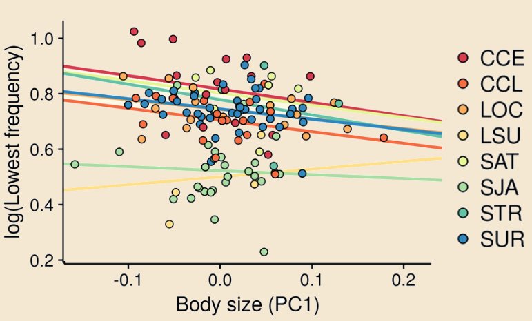

### 2.2.1 La paradoja de Simpson

La paradoja de Simpson es un fenómeno en estadística en el que una tendencia aparece en varios grupos de datos pero desaparece o se invierte cuando se combinan los grupos. Se ha utilizado para ilustrar el tipo de resultados engañosos que puede generar el ignorar la estructura en los datos y las relaciones causales entre variables.

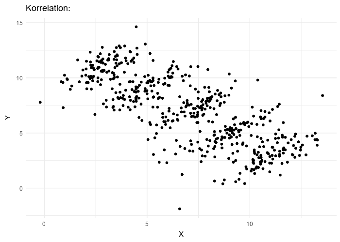

Tomado de wikipedia

La estructura de los datos debido a observaciones pertenecientes al mismo grupo puede ser tomada en cuenta usando el grupo como un factor aleatorio, tal y como se hizo en el ejemplo anterior.

**Modelos lineales como abordaje estadístico estándar para la inferencia causal**

[figure not shown]

$\hat{Y} \sim_{función\ de\ enlace} (\beta_{o} + \beta_{grupo}) + \beta_{1} * x_{1} + \cdots + \beta_{n} * x_{n}$

- Este modelo básico incluye una función de enlace que cuando es gausiana (i.e. normal) equivale a un modelo lineal y cuando no, a un modelo generalizado
- Cuando el $\beta_{grupo}$ es diferente entre grupos (i.e. cuando el intercepto difiere entre grupos) es un modelo mixto con intercepto variable (i.e. aleatorio)

Este manual solo pretende sugerir un abordaje estadístico centrado en los modelos de regresión desde el cual se pueden llevar a cabo adecuadamente la mayoría de los análisis estadísticos que usamos en investigación. **El manual no tiene como objetivo explicar en detalle las particularidades de los modelos generalizados y mixtos**. Note que estos modelos, principalmente los mixtos, pueden adaptarse a otras estructuras de datos mas complejas no cubiertas aquí, como lo son las pendientes aleatorias, pendientes e interceptos aleatorios, estructuras de correlación (i.e. autocorrelación espacial o temporal, pedigrís o árboles filogenéticos), medidas repetidas y el uso de pseudoreplicas, entre otras.

## 2.3 Referencias

- [Richard McElreath’s Statistical Rethinking book](https://github.com/rmcelreath/stat_rethinking_2022)
- Spake, R., Bowler, D. E., Callaghan, C. T., Blowes, S. A., Doncaster, C. P., Antao, L. H., … & Chase, J. M. (2023). [Understanding ‘it depends’ in ecology: a guide to hypothesising, visualising and interpreting statistical interactions](https://onlinelibrary.wiley.com/doi/full/10.1111/brv.12939). Biological Reviews.
- [Complete introduction to linear regression in R](https://www.machinelearningplus.com/machine-learning/complete-introduction-linear-regression-r/)
- [Linear regression in R](https://www.scribbr.com/statistics/linear-regression-in-r/)
- Harrison, X. A., Donaldson, L., Correa-Cano, M. E., Evans, J., Fisher, D. N., Goodwin, C. E., & Inger, R. (2018). [A brief introduction to mixed effects modelling and multi-model inference in ecology](https://peerj.com/articles/4794/). *PeerJ*, 6, e4794.

# Información de la sesión